# Customer Churn Prediction

In this R Notebook, I am going to predict whether a customer will churn or not based on various features.

## Introduction

Customer Churn refers to when a customer stops using a service e.g. ending a music streaming subscription service. Predicting customer churn helps a lot of industry to prepare and take different approach so that they can prevent churn or minimize it. It is very helpful in many industries but I am going to take up the telecom industry. I will try to analyze the data and predict the churn. Let’s start.

## Overview

The data I’m using is IBM Telecom dataset. You can obtain the data from [here](https://www.ibm.com/communities/analytics/watson-analytics-blog/guide-to-sample-datasets/).

#### Loading libraries

```r
library(ggplot2)
library(scales)
library(gridExtra)
library(caret)
library(randomForest)
```

Now that we have loaded important libraries, let’s go ahead and read the data.

#### Read the data

```r
data <- read.csv("C:/users/Vivek/Desktop/churn.csv", header = T, stringsAsFactors = T)
data[,1] <- as.character(data[,1])
```

#### Summary of data

Let’s have a look at the data.

```r
summary(data)
```

```
  customerID           gender     SeniorCitizen    Partner    Dependents     tenure      PhoneService
 Length:7043        Female:3488   Min.   :0.0000   No :3641   No :4933   Min.   : 0.00   No : 682
 Class :character   Male  :3555   1st Qu.:0.0000   Yes:3402   Yes:2110   1st Qu.: 9.00   Yes:6361
 Mode  :character                 Median :0.0000                         Median :29.00
                                  Mean   :0.1621                         Mean   :32.37
                                  3rd Qu.:0.0000                         3rd Qu.:55.00
                                  Max.   :1.0000                         Max.   :72.00

          MultipleLines     InternetService             OnlineSecurity              OnlineBackup
 No              :3390   DSL        :2421   No                 :3498   No                 :3088
 No phone service: 682   Fiber optic:3096   No internet service:1526   No internet service:1526
 Yes             :2971   No         :1526   Yes                :2019   Yes                :2429




            DeviceProtection              TechSupport                StreamingTV
 No                 :3095    No                 :3473   No                 :2810
 No internet service:1526    No internet service:1526   No internet service:1526
 Yes                :2422    Yes                :2044   Yes                :2707




            StreamingMovies           Contract    PaperlessBilling                   PaymentMethod
 No                 :2785   Month-to-month:3875   No :2872         Bank transfer (automatic):1544
 No internet service:1526   One year      :1473   Yes:4171         Credit card (automatic)  :1522
 Yes                :2732   Two year      :1695                    Electronic check         :2365
                                                                   Mailed check             :1612



 MonthlyCharges    TotalCharges    Churn
 Min.   : 18.25   Min.   :  18.8   No :5174
 1st Qu.: 35.50   1st Qu.: 401.4   Yes:1869
 Median : 70.35   Median :1397.5
 Mean   : 64.76   Mean   :2283.3
 3rd Qu.: 89.85   3rd Qu.:3794.7
 Max.   :118.75   Max.   :8684.8
                  NA's   :11
```

```r
head(data)
```

|  | customerID | gender | SeniorCitizen | Partner | Dependents | tenure | PhoneService | MultipleLines | InternetService | OnlineSecurity | OnlineBackup | DeviceProtection | TechSupport | StreamingTV | StreamingMovies | Contract | PaperlessBilling | PaymentMethod | MonthlyCharges | TotalCharges | Churn |
| --- | --- | --- | --- | --- | --- | --- | --- | --- | --- | --- | --- | --- | --- | --- | --- | --- | --- | --- | --- | --- | --- |
| 1 | 7590-VHVEG | Female | 0 | Yes | No | 1 | No | No phone service | DSL | No | Yes | No | No | No | No | Month-to-month | Yes | Electronic check | 29.85 | 29.85 | No |
| 2 | 5575-GNVDE | Male | 0 | No | No | 34 | Yes | No | DSL | Yes | No | Yes | No | No | No | One year | No | Mailed check | 56.95 | 1889.50 | No |
| 3 | 3668-QPYBK | Male | 0 | No | No | 2 | Yes | No | DSL | Yes | Yes | No | No | No | No | Month-to-month | Yes | Mailed check | 53.85 | 108.15 | Yes |
| 4 | 7795-CFOCW | Male | 0 | No | No | 45 | No | No phone service | DSL | Yes | No | Yes | Yes | No | No | One year | No | Bank transfer (automatic) | 42.30 | 1840.75 | No |
| 5 | 9237-HQITU | Female | 0 | No | No | 2 | Yes | No | Fiber optic | No | No | No | No | No | No | Month-to-month | Yes | Electronic check | 70.70 | 151.65 | Yes |
| 6 | 9305-CDSKC | Female | 0 | No | No | 8 | Yes | Yes | Fiber optic | No | No | Yes | No | Yes | Yes | Month-to-month | Yes | Electronic check | 99.65 | 820.50 | Yes |

```r
str(data)
```

```
'data.frame':   7043 obs. of  21 variables:
 $ customerID      : chr  "7590-VHVEG" "5575-GNVDE" "3668-QPYBK" "7795-CFOCW" ...
 $ gender          : Factor w/ 2 levels "Female","Male": 1 2 2 2 1 1 2 1 1 2 ...
 $ SeniorCitizen   : int  0 0 0 0 0 0 0 0 0 0 ...
 $ Partner         : Factor w/ 2 levels "No","Yes": 2 1 1 1 1 1 1 1 2 1 ...
 $ Dependents      : Factor w/ 2 levels "No","Yes": 1 1 1 1 1 1 2 1 1 2 ...
 $ tenure          : int  1 34 2 45 2 8 22 10 28 62 ...
 $ PhoneService    : Factor w/ 2 levels "No","Yes": 1 2 2 1 2 2 2 1 2 2 ...
 $ MultipleLines   : Factor w/ 3 levels "No","No phone service",..: 2 1 1 2 1 3 3 2 3 1 ...
 $ InternetService : Factor w/ 3 levels "DSL","Fiber optic",..: 1 1 1 1 2 2 2 1 2 1 ...
 $ OnlineSecurity  : Factor w/ 3 levels "No","No internet service",..: 1 3 3 3 1 1 1 3 1 3 ...
 $ OnlineBackup    : Factor w/ 3 levels "No","No internet service",..: 3 1 3 1 1 1 3 1 1 3 ...
 $ DeviceProtection: Factor w/ 3 levels "No","No internet service",..: 1 3 1 3 1 3 1 1 3 1 ...
 $ TechSupport     : Factor w/ 3 levels "No","No internet service",..: 1 1 1 3 1 1 1 1 3 1 ...
 $ StreamingTV     : Factor w/ 3 levels "No","No internet service",..: 1 1 1 1 1 3 3 1 3 1 ...
 $ StreamingMovies : Factor w/ 3 levels "No","No internet service",..: 1 1 1 1 1 3 1 1 3 1 ...
 $ Contract        : Factor w/ 3 levels "Month-to-month",..: 1 2 1 2 1 1 1 1 1 2 ...
 $ PaperlessBilling: Factor w/ 2 levels "No","Yes": 2 1 2 1 2 2 2 1 2 1 ...
 $ PaymentMethod   : Factor w/ 4 levels "Bank transfer (automatic)",..: 3 4 4 1 3 3 2 4 3 1 ...
 $ MonthlyCharges  : num  29.9 57 53.9 42.3 70.7 ...
 $ TotalCharges    : num  29.9 1889.5 108.2 1840.8 151.7 ...
 $ Churn           : Factor w/ 2 levels "No","Yes": 1 1 2 1 2 2 1 1 2 1 ...
```

There are 11 missing values in TotalCharges columns (look at summary). Since, it is very small percentage, we can simply remove them.

```r
dim(data)
```

[output not shown]

Now, let’s get to the wrangling part.

#### Wrangling

Convert the categorical variables to factor type.

```r
data[,3] <- as.factor(data[,3])
```

Since, customerID column is of no use in prediction, we will remove that.

```r
data[,1] <- NULL
```

#### Visualization

Let’s visualize the distribution of levels of categorical variables

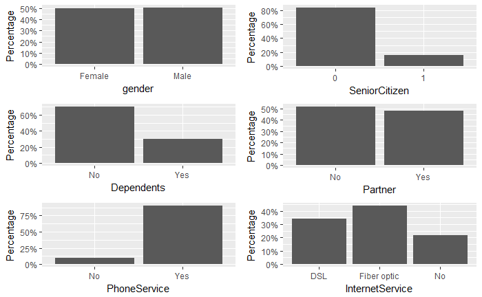

```r
p1 = ggplot(data, aes(x = gender)) +
    geom_bar(aes(y = (..count..)/sum(..count..))) + ylab("Percentage") +
    scale_y_continuous(labels  = percent)
p2 <- ggplot(data, aes(x = SeniorCitizen)) +
    geom_bar(aes(y = (..count..)/sum(..count..))) + ylab("Percentage") +
    scale_y_continuous(labels  = percent)
p3 <- ggplot(data, aes(x = Dependents)) +
    geom_bar(aes(y = (..count..)/sum(..count..))) + ylab("Percentage") +
    scale_y_continuous(labels  = percent)
p4 <- ggplot(data, aes(x = Partner)) +
    geom_bar(aes(y = (..count..)/sum(..count..))) + ylab("Percentage") +
    scale_y_continuous(labels  = percent)
p5 <- ggplot(data, aes(x = PhoneService)) +
    geom_bar(aes(y = (..count..)/sum(..count..))) + ylab("Percentage") +
    scale_y_continuous(labels  = percent)
p6 <- ggplot(data, aes(x = InternetService)) +
    geom_bar(aes(y = (..count..)/sum(..count..))) + ylab("Percentage") +
    scale_y_continuous(labels  = percent)
grid.arrange(p1,p2,p3,p4,p5,p6, ncol=2)
```

Similarly, we can visualize other categorical variables’ distribution.

Now, let’s move to the modeling part.